# STAT5003_Tutorial 2_ETRU8167

Elliot Trudgian

9/1/2020

### Melbourne House Price Regression Models

### Executive Summary:

An investment into real estate, often in the form of a primary residence, is the largest financial investment many of us will make in our lifetime. A sound understanding of how to approach valuing a residential property could save prospective homeowners tens if not hundreds of thousands of dollars on an overvalued property, or result in similair profits on an undervalued property.

In this report data from houses in Melbourne - including size, location, car spaces and price - are analysed with the aim of developing and refining a regression model that can be applied to value residential properties.

#### 1.1: Load the Data

```r
require(ggplot2)
require(ggiraph)
require(ggiraphExtra)
require(plyr)
require(scales)
MelbHousing <- read.csv("Melbourne_housing_FULL.csv", header = TRUE)
dim(MelbHousing)
```

```
## [1] 34857    21
```

```r
colnames(MelbHousing)
```

```
##  [1] "Suburb"        "Address"       "Rooms"         "Type"
##  [5] "Price"         "Method"        "SellerG"       "Date"
##  [9] "Distance"      "Postcode"      "Bedroom2"      "Bathroom"
## [13] "Car"           "Landsize"      "BuildingArea"  "YearBuilt"
## [17] "CouncilArea"   "Lattitude"     "Longtitude"    "Regionname"
## [21] "Propertycount"
```

This is a rich dataset, with nearly 35,000 entries, and 21 different variables.

#### 1.2: Initial data analysis

To make the data more manageable we only consider the suburbs of Brunswick, Craigieburn and Hawthorn.

```r
MelbHousingSubset <- subset(MelbHousing, Suburb == "Brunswick" | Suburb == "Craigieburn" | Suburb == "Hawthorn")
dim(MelbHousingSubset)
```

```
## [1] 1127   21
```

This reduces the number of entries from nearly 35,000 to just over 1,000.

All columns with NULL values for Price or Building Area are removed as they would confound the regression analysis.

```r
sum(is.na(MelbHousingSubset$Price))
```

```
## [1] 219
```

```r
MelbHousingSubset <- MelbHousingSubset[!is.na(MelbHousingSubset$Price), ]
dim(MelbHousingSubset)
```

```
## [1] 908  21
```

```r
sum(is.na(MelbHousingSubset$BuildingArea))
```

```
## [1] 490
```

```r
MelbHousingSubset <- MelbHousingSubset[!is.na(MelbHousingSubset$BuildingArea), ]
dim(MelbHousingSubset)
```

```
## [1] 418  21
```

This brings the dataset to just over 400 entries.

Initial data analysis is conducted

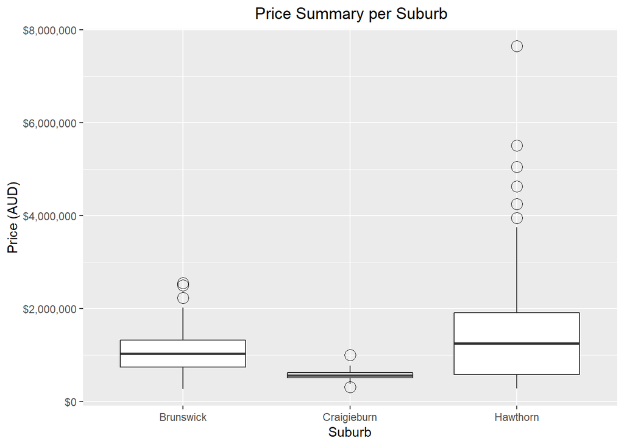

```r
plot0 <- ggplot(MelbHousingSubset, aes(x=Suburb, y=Price)) + geom_boxplot(outlier.colour="black", outlier.shape=1, outlier.size=4) + labs(
     x = "Suburb",
     y = "Price (AUD)",
     title = "                                     Price Summary per Suburb"
    )

plot0 + scale_y_continuous(labels = dollar)
```

```r
fivenum(MelbHousingSubset$Price[MelbHousingSubset$Suburb == "Brunswick"])
```

```
## [1]  272500  737500 1025500 1320000 2545000
```

```r
fivenum(MelbHousingSubset$Price[MelbHousingSubset$Suburb == "Craigieburn"])
```

```
## [1]  310000  510000  560000  616000 1000000
```

```r
fivenum(MelbHousingSubset$Price[MelbHousingSubset$Suburb == "Hawthorn"])
```

```
## [1]  275000  580000 1250000 1910000 7650000
```

#### 1.3: Finding Association 1

```r
lmBA <- lm(Price ~ BuildingArea, data = MelbHousingSubset)
```

Visualised:

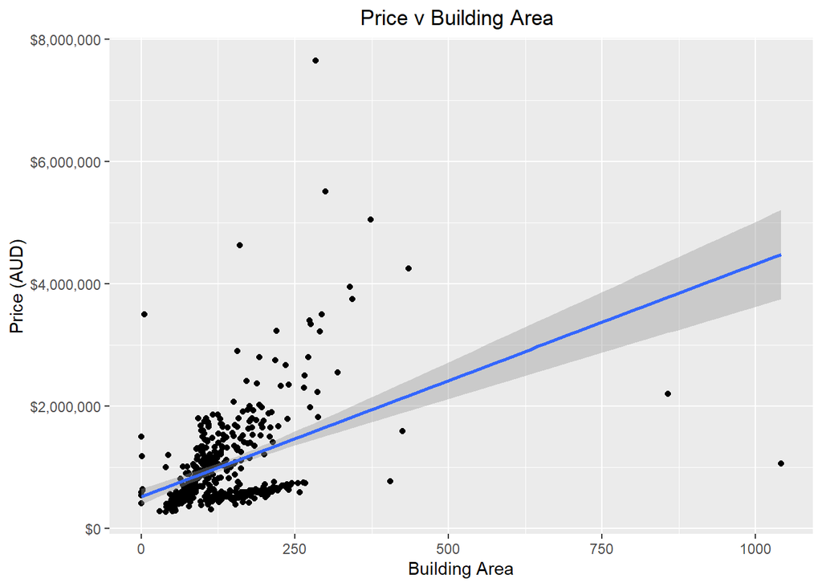

```r
plot1 <- ggplot(MelbHousingSubset, aes(x = BuildingArea, y = Price)) + geom_point() + geom_smooth(method = "lm") + labs(x = "Building Area", y = "Price (AUD)", title = "                                         Price v Building Area")
plot1 + scale_y_continuous(labels = dollar)
```

```r
summary(lmBA)
```

```
##
## Call:
## lm(formula = Price ~ BuildingArea, data = MelbHousingSubset)
##
## Residuals:
##      Min       1Q   Median       3Q      Max
## -3421769  -463874  -148030   259071  6052396
##
## Coefficients:
##              Estimate Std. Error t value Pr(>|t|)
## (Intercept)  518192.1    66595.6   7.781 5.74e-14 ***
## BuildingArea   3800.7      408.2   9.311  < 2e-16 ***
## ---
## Signif. codes:  0 '***' 0.001 '**' 0.01 '*' 0.05 '.' 0.1 ' ' 1
##
## Residual standard error: 730000 on 416 degrees of freedom
## Multiple R-squared:  0.1725, Adjusted R-squared:  0.1705
## F-statistic: 86.69 on 1 and 416 DF,  p-value: < 2.2e-16
```

The model produces a p-value less than 0.01 (2.2e-16), therefore we can conclude with 99% confidence that there is a correlation between Price and Building Area for these properties.

However, the model also produces an R-Squared Value of 0.1725. This is a poor fit and implies that Building Area only accounts for 17.25% of the variation in the observed house prices.

From observation of the plot, there are outliers that may be corrupting the model.

Consider properties with area less than 5 square metres and more than 300 square metres as outliers.

```r
outliers <- which(MelbHousingSubset$BuildingArea > 300 | MelbHousingSubset$BuildingArea < 5)
MelbHousingSubset.Clean <- MelbHousingSubset[-outliers,]
lmBA2 <- lm(Price ~ BuildingArea, data = MelbHousingSubset.Clean)
```

Visualised:

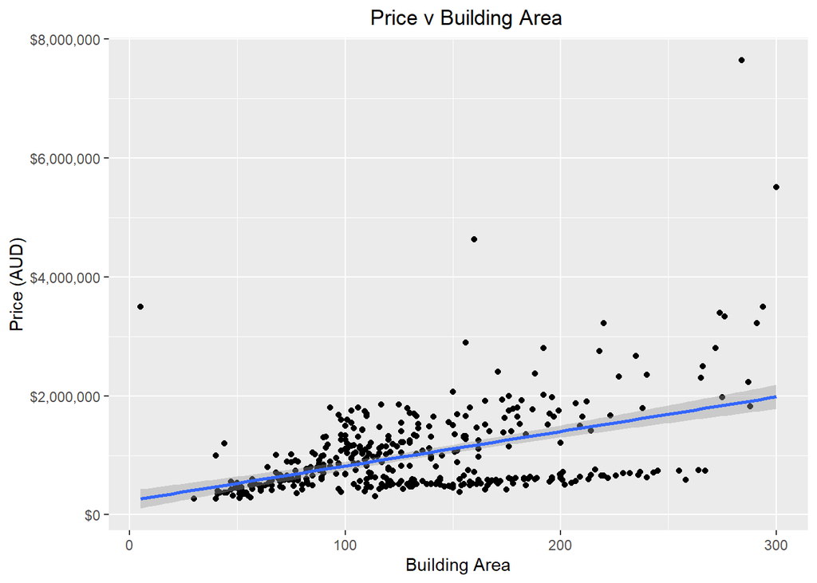

```r
plot2 <- ggplot(MelbHousingSubset.Clean, aes(x = BuildingArea, y = Price)) + geom_point() + geom_smooth(method = "lm") + labs(x = "Building Area", y = "Price (AUD)", title = "                                           Price v Building Area")
plot2 + scale_y_continuous(labels = dollar)
```

```r
summary(lmBA2)
```

```
##
## Call:
## lm(formula = Price ~ BuildingArea, data = MelbHousingSubset.Clean)
##
## Residuals:
##      Min       1Q   Median       3Q      Max
## -1154327  -428784   -66375   264834  5759663
##
## Coefficients:
##              Estimate Std. Error t value Pr(>|t|)
## (Intercept)  240852.0    83380.6   2.889  0.00408 **
## BuildingArea   5808.0      580.4  10.007  < 2e-16 ***
## ---
## Signif. codes:  0 '***' 0.001 '**' 0.01 '*' 0.05 '.' 0.1 ' ' 1
##
## Residual standard error: 663000 on 400 degrees of freedom
## Multiple R-squared:  0.2002, Adjusted R-squared:  0.1982
## F-statistic: 100.2 on 1 and 400 DF,  p-value: < 2.2e-16
```

The new model produces an R-Squared Value of 0.1982.

This is still a poor fit and implies that Building Area alone only accounts for 19.82% of the variation in house price, even after adjusting for outliers.

#### 1.4: Finding Association 2

House prices are complex and are likely to be influenced by many factors.

Extending the model to include Suburb as a second explanatory variable may increase its predictive power.

Model 3: Multiple linear regression model between Price, and Building Area and Suburb.

```r
lmBA3 <- lm(Price ~ BuildingArea + Suburb, data = MelbHousingSubset)
summary(lmBA3)
```

```
##
## Call:
## lm(formula = Price ~ BuildingArea + Suburb, data = MelbHousingSubset)
##
## Residuals:
##      Min       1Q   Median       3Q      Max
## -4074050  -248461   -26674   166018  5479862
##
## Coefficients:
##                    Estimate Std. Error t value Pr(>|t|)
## (Intercept)        509756.7    62451.0   8.163 3.99e-15 ***
## BuildingArea         4435.4      346.9  12.786  < 2e-16 ***
## SuburbCraigieburn -660277.3    72911.5  -9.056  < 2e-16 ***
## SuburbHawthorn     400715.9    72543.5   5.524 5.87e-08 ***
## ---
## Signif. codes:  0 '***' 0.001 '**' 0.01 '*' 0.05 '.' 0.1 ' ' 1
##
## Residual standard error: 609900 on 414 degrees of freedom
## Multiple R-squared:  0.425,  Adjusted R-squared:  0.4208
## F-statistic:   102 on 3 and 414 DF,  p-value: < 2.2e-16
```

As with earlier models, Model 3 produces a p-value less than 0.01 (2.2e-16), therefore we can conclude with 99% confidence that there is a correlation between Price and Building Area and Suburb for these properties.

Adding the second explanatory variable, Suburb, improves the fit of the model, increasing its explanatory power from 17.05% to 42.08%.

As Suburb is a categorical variable the interpretation of the coefficient is different than that of a numerical variable. The coefficients are binary - as opposed to scalar - inputs to the house price.

The model should be interpreted as saying that a property in Brunswick has an intercept (i.e when building area is 0) of $509,756.7, a property in Cragieburn has an intercept of -$150,520.6, and a property in Hawthorn has an intercept of $910,472.6.

Formally, the fitted lines for the three suburbs under Model 3 are:

Brunswick: Price = 509,756.7 + (4,435.4 x Building Area)

Cragieburn: Price = -150,520.6 + (4,435.4 x Building Area)

Hawthorn: Price = 910,472.6 + (4,435.4 x Building Area)

Visualised:

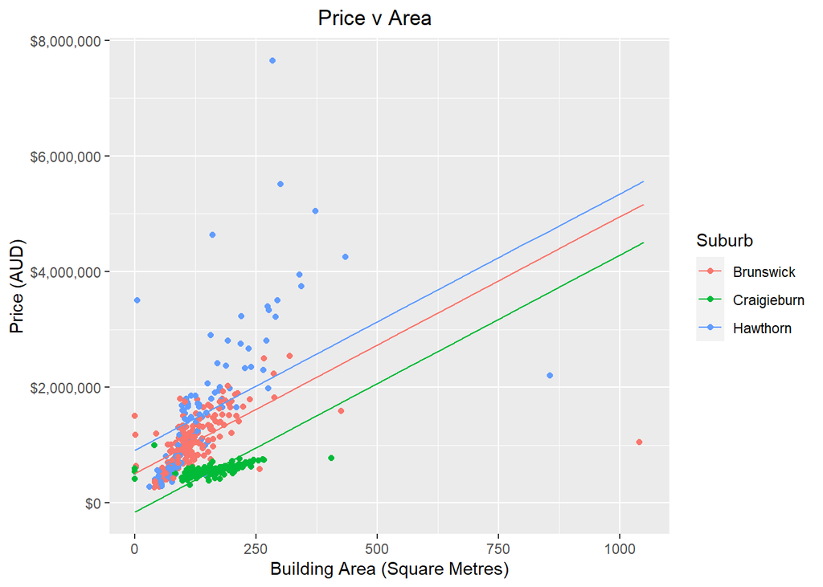

```r
plot4 <- ggPredict(lmBA3) + labs(
     x = "Building Area (Square Metres)",
     y = "Price (AUD)",
     title = "                                  Price v Area"
    )
plot4 + scale_y_continuous(labels = dollar)
```

This visualisation shows that house prices in Hawthorn are higher (all else equal) than those in Brunswick, which are higher than those in Craigieburn.

Adding a further variable - Car Spaces - to the model may further increase its predictive power.

Model 4: Multiple linear regression model between Price, and Building Area, Suburb and Car Spaces.

```r
lmBA4 <- lm(Price ~ BuildingArea + Suburb + Car, data = MelbHousingSubset)
summary(lmBA4)
```

```
##
## Call:
## lm(formula = Price ~ BuildingArea + Suburb + Car, data = MelbHousingSubset)
##
## Residuals:
##      Min       1Q   Median       3Q      Max
## -3417281  -273352   -59191   252474  5001704
##
## Coefficients:
##                    Estimate Std. Error t value Pr(>|t|)
## (Intercept)        333560.7    67011.4   4.978 9.56e-07 ***
## BuildingArea         3761.7      351.3  10.708  < 2e-16 ***
## SuburbCraigieburn -781107.7    73776.4 -10.588  < 2e-16 ***
## SuburbHawthorn     363436.8    71139.5   5.109 5.02e-07 ***
## Car                220740.5    34616.8   6.377 4.98e-10 ***
## ---
## Signif. codes:  0 '***' 0.001 '**' 0.01 '*' 0.05 '.' 0.1 ' ' 1
##
## Residual standard error: 588500 on 402 degrees of freedom
##   (11 observations deleted due to missingness)
## Multiple R-squared:  0.477,  Adjusted R-squared:  0.4718
## F-statistic: 91.66 on 4 and 402 DF,  p-value: < 2.2e-16
```

Once again the Model has a statistically significant p-value at 0.1% confidence level.

Adding the third explanatory variable, Car Spaces, has increased the explanatory power of the model from 42.08% to 47.18%

Formally, the fitted lines for the three suburbs under Model 4 are:

Brunswick: Price = 333,560.7 + (3,761.7 x Building Area) + (220,740.5 x Car Spaces)

Cragieburn: Price = -447,547.0 + (3,761.7 x Building Area) + (220,740.5 x Car Spaces)

Hawthorn: Price = 696,997.5 + (3,761.7 x Building Area) + (220,740.5 x Car Spaces)

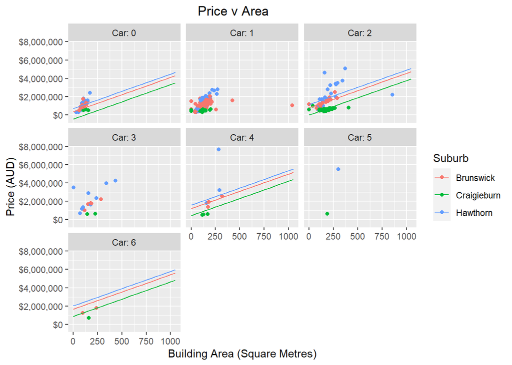

```r
plot5 <- ggPredict(lmBA4)+ labs(
     x = "Building Area (Square Metres)",
     y = "Price (AUD)",
     title = "                                  Price v Area"
    )
plot5 + scale_y_continuous(labels = dollar)
```

Analysis of Residuals is as follows:

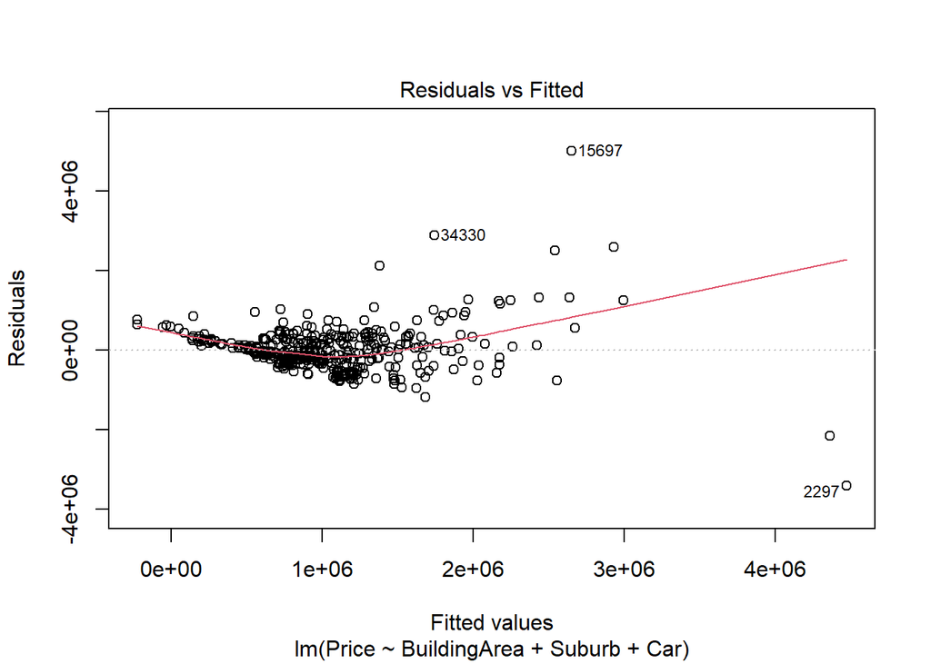

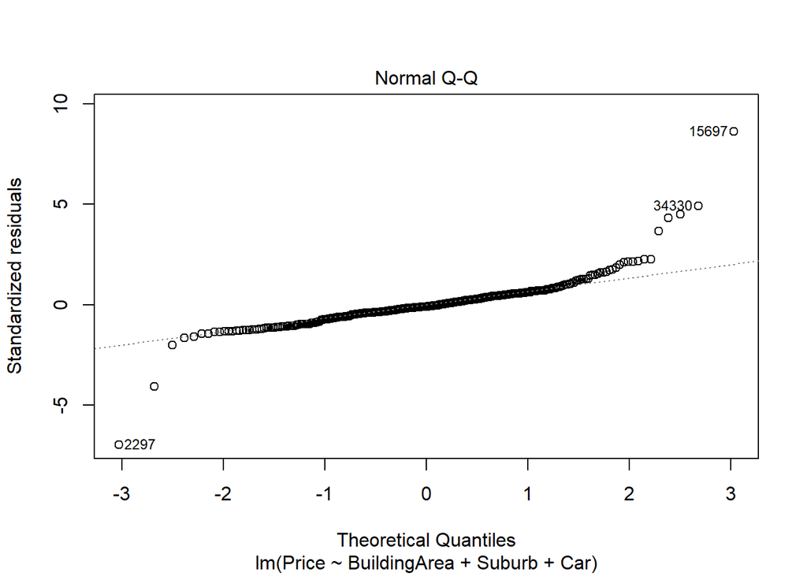

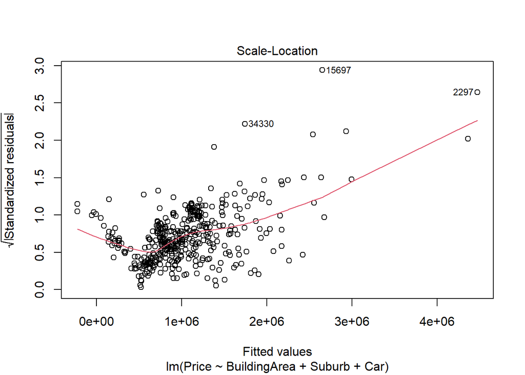

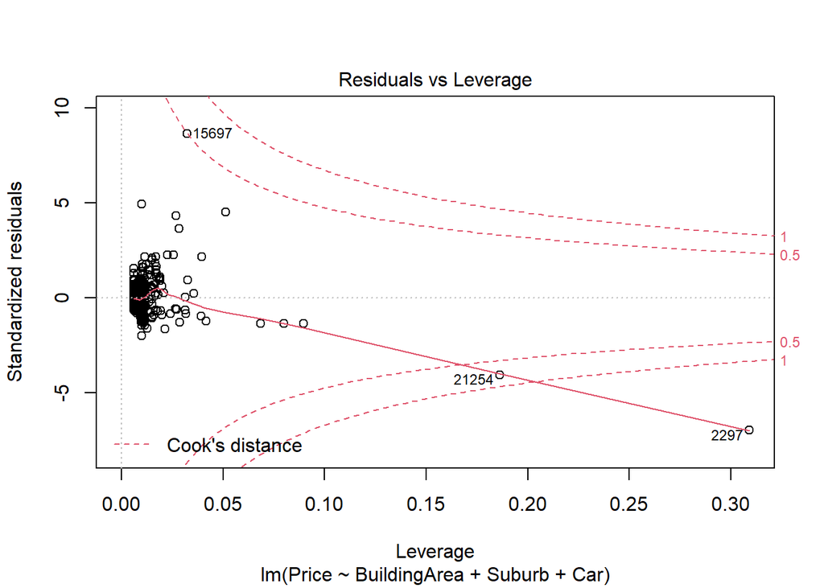

```r
plot(lmBA4)
```

From observation of the Residuals v Fitted, Normal Q-Q, Scale-Location and Residuals v Leverage plots there are outliers and highly leveraged data points that may be confounding the Model.

The Residuals v Fitted Plot identifies data points 2297, 34330 and 15697 as potential outliers.

The Normal Q-Q plot has highly skewed tails, indicating non-normality in the data, and identifies 2297, 34330 and 15697 as outliers.

The Scale-Location plot identifies 2297, 34330, and 15697 as outliers

The Residuals vs Leverage Plot identifies data point 2297 with a Cook’s distance greater than 1 and 15697 and 21254 with Cook’s distance greater than 0.5

Data points 2297, 15697, and 34330 are consistently identified as outliers and their removal may improve the Model’s predictive power.

#### 1.5: Impact of Outliers

Removing outliers (properties with Building area of more than 300 square metres, or less than 5 square metres and price higher than $6 million).

```r
outliers2 <- which(MelbHousingSubset$BuildingArea > 300 | MelbHousingSubset$BuildingArea < 5 | MelbHousingSubset$Price > 6000000)
MelbHousingSubset.Clean2 <- MelbHousingSubset[-outliers2,]
```

Model 5: Multiple linear regression model between Price, and Building Area, Suburb and Car Spaces with outliers removed.

```r
lmBA5 <- lm(Price ~ BuildingArea + Suburb + Car, data = MelbHousingSubset.Clean2)
summary(lmBA5)
```

```
##
## Call:
## lm(formula = Price ~ BuildingArea + Suburb + Car, data = MelbHousingSubset.Clean2)
##
## Residuals:
##      Min       1Q   Median       3Q      Max
## -1501042  -261971   -47724   203095  2923693
##
## Coefficients:
##                    Estimate Std. Error t value Pr(>|t|)
## (Intercept)         77328.8    58595.1   1.320  0.18771
## BuildingArea         7509.3      430.4  17.447  < 2e-16 ***
## SuburbCraigieburn -874561.7    55269.6 -15.824  < 2e-16 ***
## SuburbHawthorn     284870.8    51868.1   5.492 7.22e-08 ***
## Car                 71307.8    26385.7   2.703  0.00719 **
## ---
## Signif. codes:  0 '***' 0.001 '**' 0.01 '*' 0.05 '.' 0.1 ' ' 1
##
## Residual standard error: 419700 on 385 degrees of freedom
##   (11 observations deleted due to missingness)
## Multiple R-squared:  0.6099, Adjusted R-squared:  0.6059
## F-statistic: 150.5 on 4 and 385 DF,  p-value: < 2.2e-16
```

Removing outliers has improved the fit of our model. Increasing its explanatory power from 47.18% to 60.59%

Residual analysis is conducted again, after the removal of outliers.

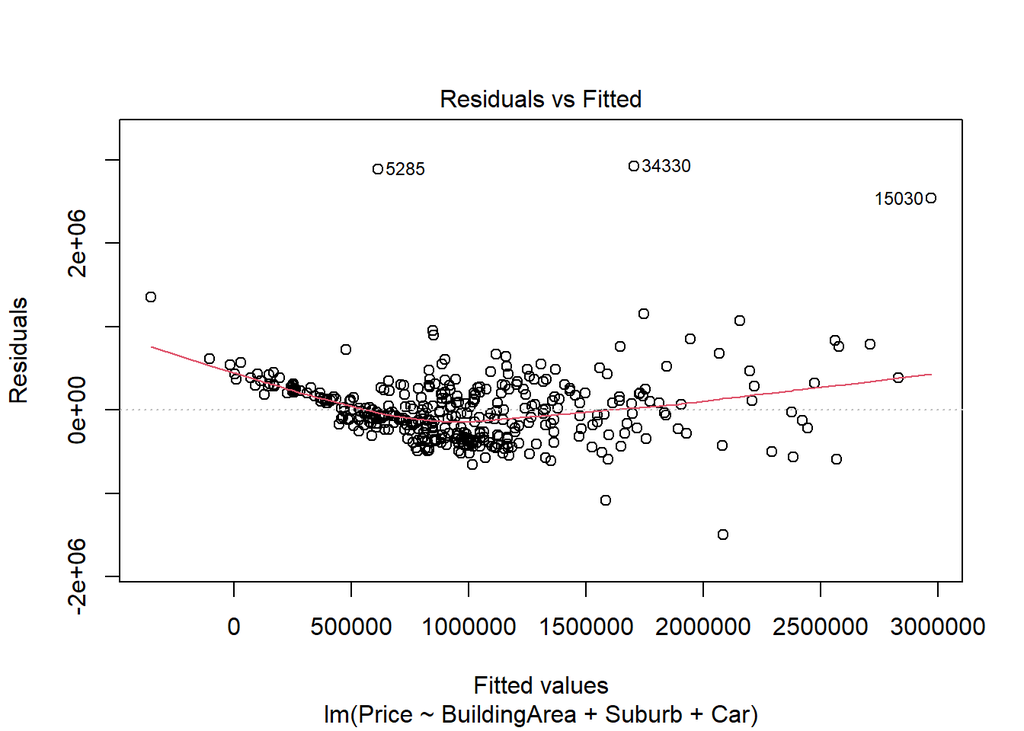

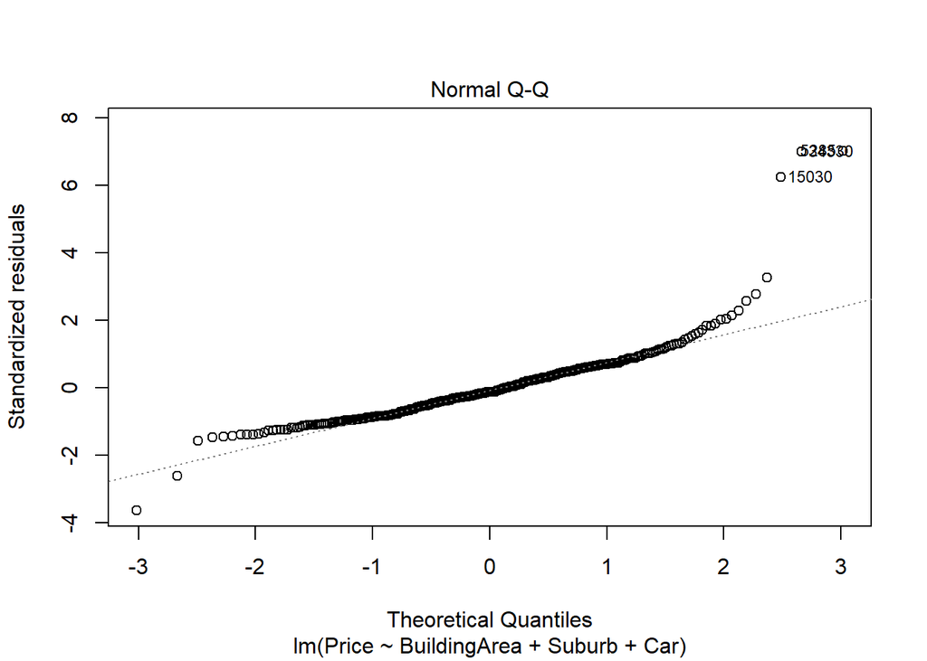

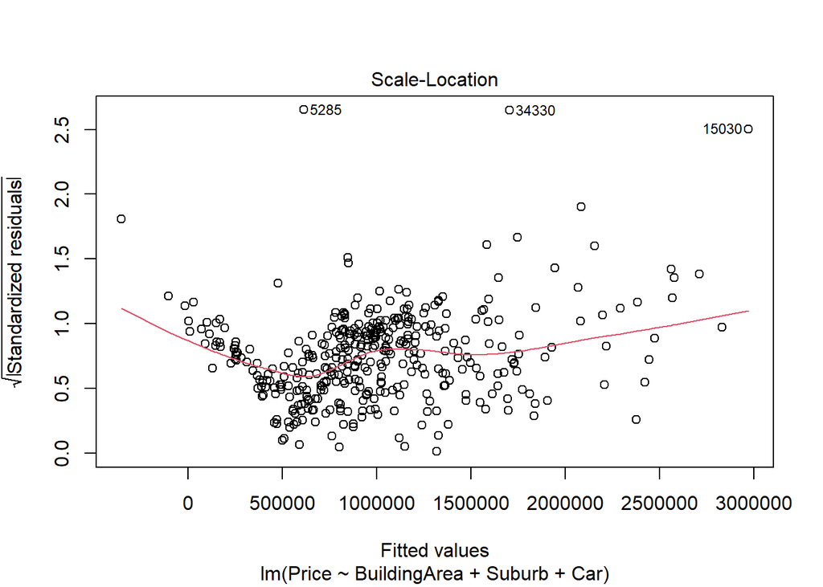

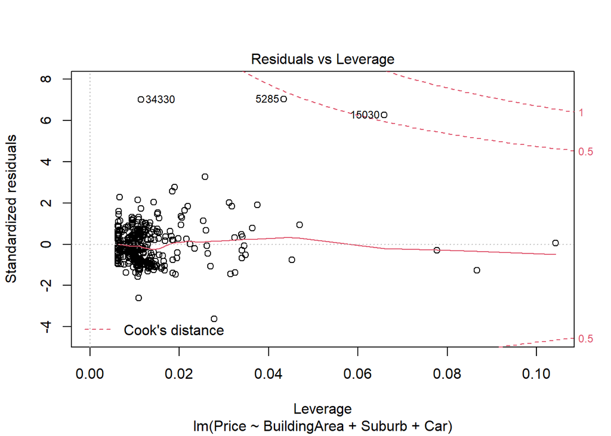

```r
plot(lmBA5)
```

#### 1.6: Prediction

We can use our final model to predict the house price of a property in Hawthorn, with two car spaces and 100sqm building area.

```r
NewHouse <- data.frame(BuildingArea = c(100),
                             Suburb = c("Hawthorn"),
                                Car = c(2))
Pred <- predict(lmBA5, NewHouse, interval = "confidence")
Pred
```

```
##       fit     lwr     upr
## 1 1255747 1165271 1346224
```

According to our model, we can say with 95% confidence that the value of our Hawthorn property, with 100sqm of Building Area and two car spaces, is between $1,165,271 and $1,346,224 with a mean expected value of $1,255,747.